# Librerias y funciones

```python
# Librerias
import pandas as pd
import numpy as np
import matplotlib
import matplotlib.pyplot as plt
import plotly.express as px

import seaborn as sns
from sklearn.preprocessing import OneHotEncoder
from sklearn.model_selection import train_test_split
```

```python
def plot_machine_failures(machine):
    """
    Función de visualización de las variables y los fallos que ha tenido la máquina
    """
    max_volt = machine['volt'].max()
    min_volt = machine['volt'].min()

    max_rotate = machine['rotate'].max()
    min_rotate = machine['rotate'].min()

    max_pressure = machine['pressure'].max()
    min_pressure = machine['pressure'].min()

    max_vibration = machine['vibration'].max()
    min_vibration = machine['vibration'].min()



    fig, ax = plt.subplots(4, figsize=(20, 15))
    ax[0].plot(machine['datetime'], machine['volt'], linewidth=0.3)
    ax[0].set_ylabel('volt')

    ax[1].plot(machine['datetime'], machine['rotate'], linewidth=0.3)
    ax[1].set_ylabel('rotate')

    ax[2].plot(machine['datetime'], machine['pressure'], linewidth=0.3)
    ax[2].set_ylabel('pressure')

    ax[3].plot(machine['datetime'], machine['vibration'], linewidth=0.3)
    ax[3].set_ylabel('vibration')

    for index, row in machine.iterrows():
        if row['comp1'] == 1:
            ax[0].vlines(x=row['datetime'], ymin=min_volt, ymax= max_volt, linestyles='dashed', color='red')
            ax[1].vlines(x=row['datetime'], ymin=min_rotate, ymax= max_rotate, linestyles='dashed', color='red')
            ax[2].vlines(x=row['datetime'], ymin=min_pressure, ymax= max_pressure, linestyles='dashed', color='red')
            ax[3].vlines(x=row['datetime'], ymin=min_vibration, ymax= max_vibration, linestyles='dashed', color='red')
        if row['comp2'] == 1:
            ax[0].vlines(x=row['datetime'], ymin=min_volt, ymax= max_volt, linestyles='dashed', color='orange')
            ax[1].vlines(x=row['datetime'], ymin=min_rotate, ymax= max_rotate, linestyles='dashed', color='orange')
            ax[2].vlines(x=row['datetime'], ymin=min_pressure, ymax= max_pressure, linestyles='dashed', color='orange')
            ax[3].vlines(x=row['datetime'], ymin=min_vibration, ymax= max_vibration, linestyles='dashed', color='orange')
        if row['comp3'] == 1:
            ax[0].vlines(x=row['datetime'], ymin=min_volt, ymax= max_volt, linestyles='dashed', color='black')
            ax[1].vlines(x=row['datetime'], ymin=min_rotate, ymax= max_rotate, linestyles='dashed', color='black')
            ax[2].vlines(x=row['datetime'], ymin=min_pressure, ymax= max_pressure, linestyles='dashed', color='black')
            ax[3].vlines(x=row['datetime'], ymin=min_vibration, ymax= max_vibration, linestyles='dashed', color='black')
        if row['comp4'] == 1:
            ax[0].vlines(x=row['datetime'], ymin=min_volt, ymax= max_volt, linestyles='dashed', color='gray')
            ax[1].vlines(x=row['datetime'], ymin=min_rotate, ymax= max_rotate, linestyles='dashed', color='gray')
            ax[2].vlines(x=row['datetime'], ymin=min_pressure, ymax= max_pressure, linestyles='dashed', color='gray')
            ax[3].vlines(x=row['datetime'], ymin=min_vibration, ymax= max_vibration, linestyles='dashed', color='gray')

    plt.show()

def calculate_RUL_cycle(df, column='failure', pre1=3, pre2=24):
    """
    Función para calcular el RUL de los ciclos hasta el fallo de la máquina.

    Se obtiene una lista de dataframes con de cada ciclo de trabajo (hasta el fallo)
    """
    df_fail = df[df[column] == 1]
    temp = []
    initial = 0
    df_rul = df.copy()
    df_rul = df_rul.assign(volt_3h_mean=0, rotate_3h_mean=0, pressure_3h_mean=0, vibration_3h_mean=0,
                           volt_24h_mean=0, rotate_24h_mean=0, pressure_24h_mean=0, vibration_24h_mean=0,
                           error1_count=0, error2_count=0, error3_count=0, error4_count=0, error5_count=0, RUL=0)
    for row_fail in df_fail.index:
        df_rul.iloc[initial:row_fail+1, df_rul.columns.get_loc('volt_3h_mean')] = df_rul.iloc[initial:row_fail+1, df_rul.columns.get_loc('volt')].rolling(pre1, min_periods=1, center=False).mean()
        df_rul.iloc[initial:row_fail+1, df_rul.columns.get_loc('rotate_3h_mean')] = df_rul.iloc[initial:row_fail+1, df_rul.columns.get_loc('rotate')].rolling(pre1, min_periods=1, center=False).mean()
        df_rul.iloc[initial:row_fail+1, df_rul.columns.get_loc('pressure_3h_mean')] = df_rul.iloc[initial:row_fail+1, df_rul.columns.get_loc('pressure')].rolling(pre1, min_periods=1, center=False).mean()
        df_rul.iloc[initial:row_fail+1, df_rul.columns.get_loc('vibration_3h_mean')] = df_rul.iloc[initial:row_fail+1, df_rul.columns.get_loc('vibration')].rolling(pre1, min_periods=1, center=False).mean()

        df_rul.iloc[initial:row_fail+1, df_rul.columns.get_loc('volt_24h_mean')] = df_rul.iloc[initial:row_fail+1, df_rul.columns.get_loc('volt')].rolling(pre2, min_periods=1, center=False).mean()
        df_rul.iloc[initial:row_fail+1, df_rul.columns.get_loc('rotate_24h_mean')] = df_rul.iloc[initial:row_fail+1, df_rul.columns.get_loc('rotate')].rolling(pre2, min_periods=1, center=False).mean()
        df_rul.iloc[initial:row_fail+1, df_rul.columns.get_loc('pressure_24h_mean')] = df_rul.iloc[initial:row_fail+1, df_rul.columns.get_loc('pressure')].rolling(pre2, min_periods=1, center=False).mean()
        df_rul.iloc[initial:row_fail+1, df_rul.columns.get_loc('vibration_24h_mean')] = df_rul.iloc[initial:row_fail+1, df_rul.columns.get_loc('vibration')].rolling(pre2, min_periods=1, center=False).mean()

        df_rul.iloc[initial:row_fail+1, df_rul.columns.get_loc('error1_count')] = df_rul.iloc[initial:row_fail+1, df_rul.columns.get_loc('error1')].rolling(row_fail, min_periods=1, center=False).sum().astype(int)
        df_rul.iloc[initial:row_fail+1, df_rul.columns.get_loc('error2_count')] = df_rul.iloc[initial:row_fail+1, df_rul.columns.get_loc('error2')].rolling(row_fail, min_periods=1, center=False).sum().astype(int)
        df_rul.iloc[initial:row_fail+1, df_rul.columns.get_loc('error3_count')] = df_rul.iloc[initial:row_fail+1, df_rul.columns.get_loc('error3')].rolling(row_fail, min_periods=1, center=False).sum().astype(int)
        df_rul.iloc[initial:row_fail+1, df_rul.columns.get_loc('error4_count')] = df_rul.iloc[initial:row_fail+1, df_rul.columns.get_loc('error4')].rolling(row_fail, min_periods=1, center=False).sum().astype(int)
        df_rul.iloc[initial:row_fail+1, df_rul.columns.get_loc('error5_count')] = df_rul.iloc[initial:row_fail+1, df_rul.columns.get_loc('error5')].rolling(row_fail, min_periods=1, center=False).sum().astype(int)

        df_rul.iloc[initial:row_fail+1, df_rul.columns.get_loc('RUL')] = pd.Series(range(row_fail, -1, -1))

        temp.append(df_rul.iloc[initial:row_fail+1])
        initial = row_fail + 1
    df_rul = df_rul.drop(df.index[row_fail+1:len(df_rul)])
    return temp

def cut_cycle(cycle_lst, min_cycle=0, threshold = 480, flat = False):
    """
    Función para que permite "aplanar" la lista obtenida de calculate_RUL_cycle
    Tambíen permite normalizar los ciclos de trabajo según el número minimo de muestras
    que este por encima del threshold. Este normalizado se aplica a todos los ciclos de la lista

    Se obteniene una lista solamente con los ciclos que cumplan con el mínimo de muestras
    También se obtniene el mínimo de muestras por ciclo encontrado
    """
    machine_m3_rul_cycle_norm = []

    if flat == False:
        cycle_lst = [item for items in cycle_lst for item in items]

    if min_cycle == 0:
        min_cycle = min(len(df) for df in cycle_lst if len(df) > threshold)

    for df in cycle_lst:
        if len(df) >= min_cycle:
            machine_m3_rul_cycle_norm.append(df.tail(min_cycle))
    return machine_m3_rul_cycle_norm, min_cycle
```

# Carga de datos

```python
# DATA_DIR = "C:/Users/NetRunner/OneDrive/UOC/Semestre 6/TFM/Data 2"
DATA_DIR = "C:/Users/NetRunner/OneDrive/UOC/Semestre 6/TFM/Data 2"


dataset = pd.read_csv(f"{DATA_DIR}/Dataset.csv")
dataset['datetime'] = pd.to_datetime(dataset['datetime'])
dataset.head()
```

|  | datetime | machineID | volt | rotate | pressure | vibration | error1 | error2 | error3 | error4 | error5 | comp1 | comp2 | comp3 | comp4 | failure | model | age |
| --- | --- | --- | --- | --- | --- | --- | --- | --- | --- | --- | --- | --- | --- | --- | --- | --- | --- | --- |
| 0 | 2015-01-01 06:00:00 | 1 | 176.217853 | 418.504078 | 113.077935 | 45.087686 | 0 | 0 | 0 | 0 | 0 | 0 | 0 | 0 | 0 | 0 | model3 | 18 |
| 1 | 2015-01-01 06:00:00 | 2 | 176.558913 | 424.624162 | 76.005332 | 43.767049 | 0 | 0 | 0 | 0 | 0 | 0 | 0 | 0 | 0 | 0 | model4 | 7 |
| 2 | 2015-01-01 06:00:00 | 3 | 185.482043 | 461.211137 | 87.453199 | 28.216864 | 0 | 0 | 0 | 0 | 0 | 0 | 0 | 0 | 0 | 0 | model3 | 8 |
| 3 | 2015-01-01 06:00:00 | 4 | 169.710847 | 463.646727 | 95.929877 | 38.400372 | 0 | 0 | 0 | 0 | 0 | 0 | 0 | 0 | 0 | 0 | model3 | 7 |
| 4 | 2015-01-01 06:00:00 | 5 | 165.082899 | 452.283576 | 84.591722 | 40.298803 | 0 | 0 | 0 | 0 | 0 | 0 | 0 | 0 | 0 | 0 | model3 | 2 |

```python
# Lectura de datos
DATA_DIR = "C:/Users/NetRunner/OneDrive/UOC/Semestre 6/TFM/Data"

telemetry_df = pd.read_csv(f"{DATA_DIR}/PdM_telemetry.csv")
errors_df = pd.read_csv(f"{DATA_DIR}/PdM_errors.csv")
maint_df = pd.read_csv(f"{DATA_DIR}/PdM_maint.csv")
failures_df = pd.read_csv(f"{DATA_DIR}/PdM_failures.csv")
machines_df = pd.read_csv(f"{DATA_DIR}/PdM_machines.csv")
```

### Separación de datasets por modelo e ID

Se ha seleccionado las màquinas del mismo modelo y con la misma edad para considerar-los como un único conjunto

```python
machine_m3_15 = dataset[(dataset['model']=='model3') & (dataset['machineID']==15)].copy().reset_index().drop('index', axis=1)
machine_m3_33 = dataset[(dataset['model']=='model3') & (dataset['machineID']==33)].copy().reset_index().drop('index', axis=1)
machine_m3_43 = dataset[(dataset['model']=='model3') & (dataset['machineID']==43)].copy().reset_index().drop('index', axis=1)
machine_m3_45 = dataset[(dataset['model']=='model3') & (dataset['machineID']==45)].copy().reset_index().drop('index', axis=1)
machine_m3_52 = dataset[(dataset['model']=='model3') & (dataset['machineID']==52)].copy().reset_index().drop('index', axis=1)
machine_m3_79 = dataset[(dataset['model']=='model3') & (dataset['machineID']==79)].copy().reset_index().drop('index', axis=1)

machine_m3 = [machine_m3_15, machine_m3_33, machine_m3_43, machine_m3_45, machine_m3_52]
```

```python
machine_m3_79.head()
```

|  | datetime | machineID | volt | rotate | pressure | vibration | error1 | error2 | error3 | error4 | error5 | comp1 | comp2 | comp3 | comp4 | failure | model | age |
| --- | --- | --- | --- | --- | --- | --- | --- | --- | --- | --- | --- | --- | --- | --- | --- | --- | --- | --- |
| 0 | 2015-01-01 06:00:00 | 79 | 194.167651 | 535.302327 | 84.071434 | 35.654640 | 0 | 0 | 0 | 0 | 0 | 0 | 0 | 0 | 0 | 0 | model3 | 14 |
| 1 | 2015-01-01 07:00:00 | 79 | 180.989438 | 429.031142 | 96.245928 | 37.163490 | 0 | 0 | 0 | 0 | 0 | 0 | 0 | 0 | 0 | 0 | model3 | 14 |
| 2 | 2015-01-01 08:00:00 | 79 | 208.452257 | 374.095525 | 106.340279 | 37.617635 | 0 | 0 | 0 | 0 | 0 | 0 | 0 | 0 | 0 | 0 | model3 | 14 |
| 3 | 2015-01-01 09:00:00 | 79 | 192.161379 | 438.784836 | 94.309427 | 47.383279 | 0 | 0 | 0 | 0 | 0 | 0 | 0 | 0 | 0 | 0 | model3 | 14 |
| 4 | 2015-01-01 10:00:00 | 79 | 207.822427 | 391.115326 | 103.079753 | 39.579032 | 0 | 0 | 0 | 0 | 0 | 0 | 0 | 0 | 0 | 0 | model3 | 14 |

```python
machine_m3_79.columns
```

```
Index(['datetime', 'machineID', 'volt', 'rotate', 'pressure', 'vibration',
       'error1', 'error2', 'error3', 'error4', 'error5', 'comp1', 'comp2',
       'comp3', 'comp4', 'failure', 'model', 'age'],
      dtype='object')
```

### Correlaciones

```python
# Generamos matriz lista  de dataframes con los ciclos y rul
machine_m3_rul_cycle = []
for machine in machine_m3:
    machine_m3_rul_cycle.append(calculate_RUL_cycle(machine))

# Cortamos los filtros por el mínimo de muestras que queremos sobre la lista de ciclos
min_cycle = 0
muestras = 500

machine_m3_rul_cycle_cut, min_cycle = cut_cycle(machine_m3_rul_cycle, min_cycle, muestras)

# Realizamos lo mismo para la otra
machine_m3_79_rul_cycle = calculate_RUL_cycle(machine_m3_79)
machine_m3_79_rul_cycle_cut, _ = cut_cycle(machine_m3_79_rul_cycle, min_cycle, 500, True)

# Concatenamos todos los dataframes de las listas para generar un dataframe único
machine_m3_rul_cycle_cut = pd.concat(machine_m3_rul_cycle_cut)
machine_m3_79_rul_cycle_cut = pd.concat(machine_m3_79_rul_cycle_cut)

temp_l = [pd.concat(machine_m3_rul_cycle[0]), pd.concat(machine_m3_rul_cycle[1]), pd.concat(machine_m3_rul_cycle[2]), pd.concat(machine_m3_rul_cycle[3]), pd.concat(machine_m3_rul_cycle[4])]
machine_m3_rul_cycle_uncut = pd.concat(temp_l)
machine_m3_79_rul_cycle_uncut = pd.concat(machine_m3_79_rul_cycle)

machine_m3_79_rul_cycle_uncut = machine_m3_79_rul_cycle_uncut[['datetime', 'volt', 'rotate',
                                                               'pressure', 'vibration','error1', 'error2',
                                                               'error3', 'error4', 'error5', 'model', 'RUL']]
machine_m3_79_rul_cycle_uncut[:22]
```

|  | datetime | volt | rotate | pressure | vibration | error1 | error2 | error3 | error4 | error5 | model | RUL |
| --- | --- | --- | --- | --- | --- | --- | --- | --- | --- | --- | --- | --- |
| 0 | 2015-01-01 06:00:00 | 194.167651 | 535.302327 | 84.071434 | 35.654640 | 0 | 0 | 0 | 0 | 0 | model3 | 21 |
| 1 | 2015-01-01 07:00:00 | 180.989438 | 429.031142 | 96.245928 | 37.163490 | 0 | 0 | 0 | 0 | 0 | model3 | 20 |
| 2 | 2015-01-01 08:00:00 | 208.452257 | 374.095525 | 106.340279 | 37.617635 | 0 | 0 | 0 | 0 | 0 | model3 | 19 |
| 3 | 2015-01-01 09:00:00 | 192.161379 | 438.784836 | 94.309427 | 47.383279 | 0 | 0 | 0 | 0 | 0 | model3 | 18 |
| 4 | 2015-01-01 10:00:00 | 207.822427 | 391.115326 | 103.079753 | 39.579032 | 0 | 0 | 0 | 0 | 0 | model3 | 17 |
| 5 | 2015-01-01 11:00:00 | 193.647095 | 484.526874 | 95.397495 | 32.340949 | 0 | 0 | 0 | 0 | 0 | model3 | 16 |
| 6 | 2015-01-01 12:00:00 | 201.603444 | 318.811141 | 110.102601 | 38.413517 | 0 | 0 | 0 | 0 | 0 | model3 | 15 |
| 7 | 2015-01-01 13:00:00 | 213.373747 | 489.746066 | 105.192482 | 31.554710 | 0 | 0 | 0 | 0 | 0 | model3 | 14 |
| 8 | 2015-01-01 14:00:00 | 184.497121 | 421.289094 | 94.277212 | 37.787211 | 0 | 0 | 0 | 0 | 0 | model3 | 13 |
| 9 | 2015-01-01 15:00:00 | 206.497032 | 486.085091 | 84.973548 | 37.514714 | 0 | 0 | 0 | 0 | 0 | model3 | 12 |
| 10 | 2015-01-01 16:00:00 | 206.557544 | 476.343880 | 103.187476 | 38.246337 | 0 | 0 | 0 | 0 | 0 | model3 | 11 |
| 11 | 2015-01-01 17:00:00 | 184.162078 | 473.900598 | 82.287550 | 32.353643 | 0 | 0 | 0 | 0 | 0 | model3 | 10 |
| 12 | 2015-01-01 18:00:00 | 220.870512 | 388.498630 | 101.861546 | 41.342239 | 0 | 0 | 0 | 0 | 0 | model3 | 9 |
| 13 | 2015-01-01 19:00:00 | 210.927495 | 465.994665 | 85.270919 | 37.968711 | 0 | 0 | 0 | 0 | 0 | model3 | 8 |
| 14 | 2015-01-01 20:00:00 | 177.076815 | 435.148457 | 101.058159 | 38.907672 | 0 | 0 | 0 | 0 | 0 | model3 | 7 |
| 15 | 2015-01-01 21:00:00 | 148.141444 | 410.707959 | 90.994411 | 40.245877 | 0 | 0 | 0 | 0 | 0 | model3 | 6 |
| 16 | 2015-01-01 22:00:00 | 174.140050 | 506.239512 | 120.878279 | 56.343024 | 0 | 0 | 0 | 0 | 0 | model3 | 5 |
| 17 | 2015-01-01 23:00:00 | 173.807056 | 459.251784 | 99.110984 | 35.496824 | 0 | 0 | 0 | 0 | 0 | model3 | 4 |
| 18 | 2015-01-02 00:00:00 | 201.189930 | 453.431673 | 96.072694 | 40.861517 | 0 | 0 | 0 | 0 | 0 | model3 | 3 |
| 19 | 2015-01-02 01:00:00 | 203.072918 | 505.047943 | 101.052282 | 47.169353 | 0 | 0 | 0 | 0 | 0 | model3 | 2 |
| 20 | 2015-01-02 02:00:00 | 206.128690 | 456.912575 | 97.775535 | 34.639112 | 0 | 0 | 0 | 0 | 0 | model3 | 1 |
| 21 | 2015-01-02 03:00:00 | 206.934554 | 423.353299 | 110.745533 | 35.708642 | 0 | 0 | 0 | 0 | 0 | model3 | 0 |

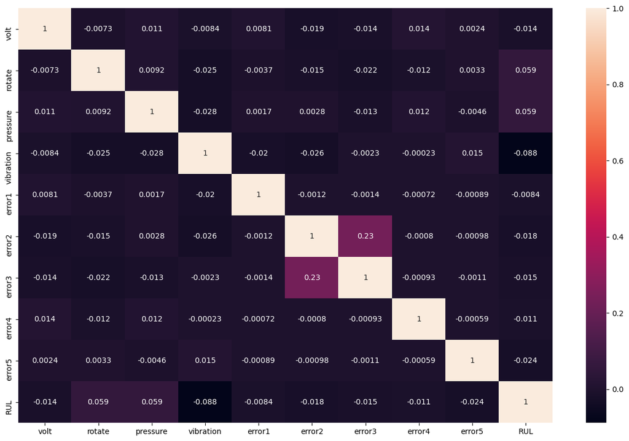

```python
#All variables correlations
plt.figure(figsize=(16, 10))
sns.heatmap(machine_m3_79_rul_cycle_uncut.corr(), annot=True)
```

### Variables de las máquinas junto a los fallos de componentes

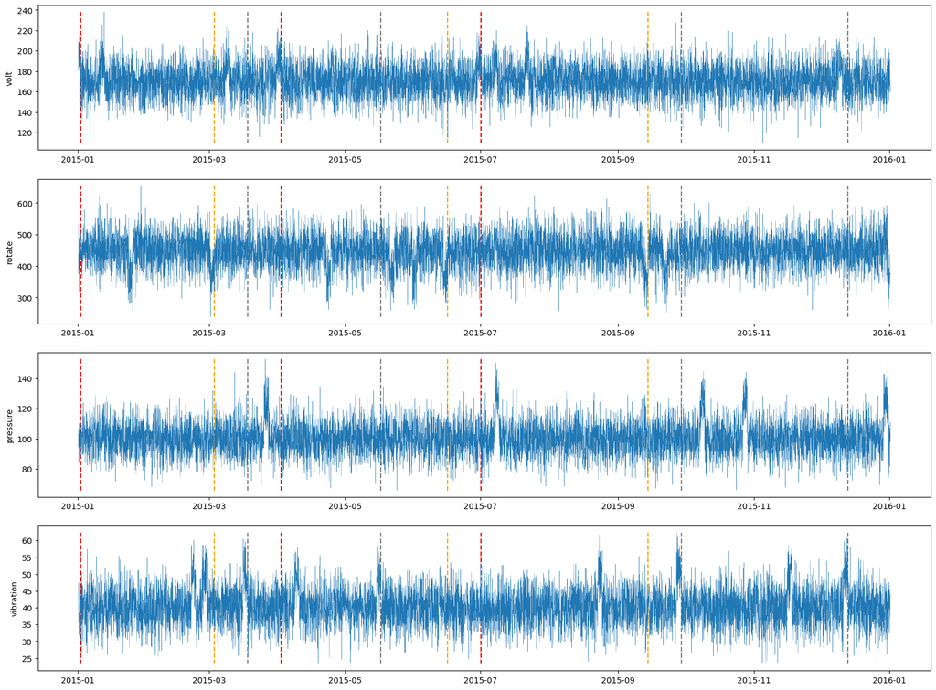

```python
plot_machine_failures(machine_m3_79)
```

# Generación de sub-Datasets con RUL y ciclos normalizados

En este sección añadimos cortamos los datos por ciclos de trabajo, es decir, desde su correcto funcionamiento hasta su próximo fallo.  
Una vez obtenido estos cyclos de trabajo añadiremos la columna RUL y State.

La columna RUL sera un valor decreciente por hora de màquina trabajado, eso significa que el primer valor del RUL de la máquina sera el máximo y este ira decreciendo a medida que pasen las horas, hasta llegar a 0 que es donde termina el ciclo con un fallo.

La columna State serà un valor categorico que permitirá saber si la máquina dejará de funcionar en las próximas horas, para hello tenemos el estado "Normal" = 0 i el estado "Warning" = 1. En este caso se considerará estado "Warning" si la máquina tendra un fallo en las próximas 72h, es decir 3 dias.

```python
# Generamos matriz lista  de dataframes con los ciclos y rul
machine_m3_rul_cycle = []
for machine in machine_m3:
    machine_m3_rul_cycle.append(calculate_RUL_cycle(machine))

# Cortamos los filtros por el mínimo de muestras que queremos sobre la lista de ciclos
min_cycle = 0
muestras = 500

machine_m3_rul_cycle_cut, min_cycle = cut_cycle(machine_m3_rul_cycle, min_cycle, muestras)

# Realizamos lo mismo para la otra
machine_m3_79_rul_cycle = calculate_RUL_cycle(machine_m3_79)
machine_m3_79_rul_cycle_cut, _ = cut_cycle(machine_m3_79_rul_cycle, min_cycle, 500, True)
```

```python
# Concatenamos todos los dataframes de las listas para generar un dataframe único
machine_m3_rul_cycle_cut = pd.concat(machine_m3_rul_cycle_cut)
machine_m3_79_rul_cycle_cut = pd.concat(machine_m3_79_rul_cycle_cut)

temp_l = [pd.concat(machine_m3_rul_cycle[0]), pd.concat(machine_m3_rul_cycle[1]), pd.concat(machine_m3_rul_cycle[2]), pd.concat(machine_m3_rul_cycle[3]), pd.concat(machine_m3_rul_cycle[4])]
machine_m3_rul_cycle_uncut = pd.concat(temp_l)
machine_m3_79_rul_cycle_uncut = pd.concat(machine_m3_79_rul_cycle)
```

```python
machine_m3_79_rul_cycle_uncut
```

|  | datetime | machineID | volt | rotate | pressure | vibration | error1 | error2 | error3 | error4 | ... | volt_24h_mean | rotate_24h_mean | pressure_24h_mean | vibration_24h_mean | error1_count | error2_count | error3_count | error4_count | error5_count | RUL |
| --- | --- | --- | --- | --- | --- | --- | --- | --- | --- | --- | --- | --- | --- | --- | --- | --- | --- | --- | --- | --- | --- |
| 0 | 2015-01-01 06:00:00 | 79 | 194.167651 | 535.302327 | 84.071434 | 35.654640 | 0 | 0 | 0 | 0 | ... | 194.167651 | 535.302327 | 84.071434 | 35.654640 | 0 | 0 | 0 | 0 | 0 | 21 |
| 1 | 2015-01-01 07:00:00 | 79 | 180.989438 | 429.031142 | 96.245928 | 37.163490 | 0 | 0 | 0 | 0 | ... | 187.578545 | 482.166735 | 90.158681 | 36.409065 | 0 | 0 | 0 | 0 | 0 | 20 |
| 2 | 2015-01-01 08:00:00 | 79 | 208.452257 | 374.095525 | 106.340279 | 37.617635 | 0 | 0 | 0 | 0 | ... | 194.536449 | 446.142998 | 95.552547 | 36.811922 | 0 | 0 | 0 | 0 | 0 | 19 |
| 3 | 2015-01-01 09:00:00 | 79 | 192.161379 | 438.784836 | 94.309427 | 47.383279 | 0 | 0 | 0 | 0 | ... | 193.942681 | 444.303458 | 95.241767 | 39.454761 | 0 | 0 | 0 | 0 | 0 | 18 |
| 4 | 2015-01-01 10:00:00 | 79 | 207.822427 | 391.115326 | 103.079753 | 39.579032 | 0 | 0 | 0 | 0 | ... | 196.718630 | 433.665831 | 96.809364 | 39.479615 | 0 | 0 | 0 | 0 | 0 | 17 |
| ... | ... | ... | ... | ... | ... | ... | ... | ... | ... | ... | ... | ... | ... | ... | ... | ... | ... | ... | ... | ... | ... |
| 8300 | 2015-12-13 02:00:00 | 79 | 186.760444 | 433.024336 | 95.642356 | 57.879780 | 0 | 0 | 0 | 0 | ... | 170.637997 | 451.481347 | 96.920153 | 50.601079 | 2 | 1 | 4 | 1 | 1 | 4 |
| 8301 | 2015-12-13 03:00:00 | 79 | 168.397729 | 394.397016 | 100.890146 | 55.963847 | 0 | 0 | 0 | 0 | ... | 170.454144 | 448.149948 | 96.338139 | 51.050714 | 2 | 1 | 4 | 1 | 1 | 3 |
| 8302 | 2015-12-13 04:00:00 | 79 | 175.738158 | 449.913107 | 115.431667 | 43.352411 | 0 | 0 | 0 | 0 | ... | 170.059111 | 447.504322 | 97.039380 | 50.664771 | 2 | 1 | 4 | 1 | 1 | 2 |
| 8303 | 2015-12-13 05:00:00 | 79 | 193.264043 | 489.664303 | 87.368971 | 47.780141 | 0 | 0 | 0 | 0 | ... | 171.020446 | 448.102066 | 96.323838 | 50.580062 | 2 | 1 | 4 | 1 | 1 | 1 |
| 8304 | 2015-12-13 06:00:00 | 79 | 166.747733 | 530.176778 | 80.825280 | 45.902295 | 0 | 0 | 0 | 0 | ... | 170.384790 | 453.838179 | 95.497808 | 50.486227 | 2 | 1 | 4 | 1 | 1 | 0 |

8305 rows × 32 columns

```python
# Añadimos la columna State
machine_m3_rul_cycle_cut['State'] = np.where(machine_m3_rul_cycle_cut['RUL'] <= 72, 1, 0)
machine_m3_79_rul_cycle_cut['State'] = np.where(machine_m3_79_rul_cycle_cut['RUL'] <= 72, 1, 0)

# Añadimos la columna State
machine_m3_rul_cycle_uncut['State'] = np.where(machine_m3_rul_cycle_uncut['RUL'] <= 72, 1, 0)
machine_m3_79_rul_cycle_uncut['State'] = np.where(machine_m3_79_rul_cycle_uncut['RUL'] <= 72, 1, 0)
```

# Datasets generados

### machine_m3_rul_cycle_cut

Dataset de las máquinas de modelo 3, con su rul calculado y seleccionado los ciclos normalizados

```python
machine_m3_rul_cycle_cut
```

|  | datetime | machineID | volt | rotate | pressure | vibration | error1 | error2 | error3 | error4 | ... | rotate_24h_mean | pressure_24h_mean | vibration_24h_mean | error1_count | error2_count | error3_count | error4_count | error5_count | RUL | State |
| --- | --- | --- | --- | --- | --- | --- | --- | --- | --- | --- | --- | --- | --- | --- | --- | --- | --- | --- | --- | --- | --- |
| 2977 | 2015-05-05 07:00:00 | 15 | 158.809093 | 519.491804 | 89.943126 | 45.862285 | 0 | 0 | 0 | 0 | ... | 463.744623 | 100.058665 | 40.347160 | 4 | 3 | 0 | 1 | 1 | 719 | 0 |
| 2978 | 2015-05-05 08:00:00 | 15 | 133.369103 | 500.095396 | 90.904882 | 30.850557 | 0 | 0 | 0 | 0 | ... | 464.839572 | 99.564608 | 39.898338 | 4 | 3 | 0 | 1 | 1 | 718 | 0 |
| 2979 | 2015-05-05 09:00:00 | 15 | 160.381456 | 439.088244 | 99.668807 | 37.620321 | 0 | 0 | 0 | 0 | ... | 461.226552 | 99.530791 | 39.754684 | 4 | 3 | 0 | 1 | 1 | 717 | 0 |
| 2980 | 2015-05-05 10:00:00 | 15 | 172.735191 | 550.954690 | 112.886843 | 45.702312 | 0 | 0 | 0 | 0 | ... | 466.948133 | 99.873709 | 40.096415 | 4 | 3 | 0 | 1 | 1 | 716 | 0 |
| 2981 | 2015-05-05 11:00:00 | 15 | 171.673821 | 498.732058 | 95.322091 | 39.311040 | 0 | 0 | 0 | 0 | ... | 467.525822 | 99.197645 | 40.081451 | 4 | 3 | 0 | 1 | 1 | 715 | 0 |
| ... | ... | ... | ... | ... | ... | ... | ... | ... | ... | ... | ... | ... | ... | ... | ... | ... | ... | ... | ... | ... | ... |
| 8708 | 2015-12-30 02:00:00 | 52 | 166.161254 | 515.775881 | 94.914844 | 48.511206 | 0 | 0 | 0 | 0 | ... | 453.138098 | 96.898645 | 49.326675 | 2 | 1 | 0 | 1 | 1 | 4 | 1 |
| 8709 | 2015-12-30 03:00:00 | 52 | 179.275310 | 418.558892 | 81.251350 | 54.070050 | 0 | 0 | 0 | 0 | ... | 454.023081 | 95.806610 | 49.650518 | 2 | 1 | 0 | 1 | 1 | 3 | 1 |
| 8710 | 2015-12-30 04:00:00 | 52 | 198.275985 | 477.652781 | 100.145070 | 42.757978 | 0 | 0 | 0 | 0 | ... | 455.883615 | 95.432664 | 49.418555 | 2 | 1 | 0 | 1 | 1 | 2 | 1 |
| 8711 | 2015-12-30 05:00:00 | 52 | 182.156321 | 534.983527 | 82.099477 | 45.139395 | 0 | 0 | 0 | 0 | ... | 459.872017 | 94.710077 | 48.992301 | 2 | 1 | 0 | 1 | 1 | 1 | 1 |
| 8712 | 2015-12-30 06:00:00 | 52 | 157.309819 | 362.760911 | 100.335067 | 56.812017 | 0 | 0 | 0 | 0 | ... | 457.491174 | 93.970252 | 49.537220 | 2 | 1 | 0 | 1 | 1 | 0 | 1 |

17280 rows × 33 columns

### machine_m3_79_rul_cycle_cut

Dataset de las máquinas de modelo 3 e ID 79, con su rul calculado y seleccionado los ciclos normalizados

```python
machine_m3_79_rul_cycle_cut
```

|  | datetime | machineID | volt | rotate | pressure | vibration | error1 | error2 | error3 | error4 | ... | rotate_24h_mean | pressure_24h_mean | vibration_24h_mean | error1_count | error2_count | error3_count | error4_count | error5_count | RUL | State |
| --- | --- | --- | --- | --- | --- | --- | --- | --- | --- | --- | --- | --- | --- | --- | --- | --- | --- | --- | --- | --- | --- |
| 745 | 2015-02-01 07:00:00 | 79 | 171.585268 | 480.714388 | 123.036718 | 36.549834 | 0 | 0 | 0 | 0 | ... | 461.654747 | 101.428542 | 39.133370 | 0 | 0 | 1 | 0 | 0 | 719 | 0 |
| 746 | 2015-02-01 08:00:00 | 79 | 180.671569 | 401.104200 | 98.973284 | 35.288739 | 0 | 0 | 0 | 0 | ... | 454.048837 | 101.542633 | 38.909825 | 0 | 0 | 1 | 0 | 0 | 718 | 0 |
| 747 | 2015-02-01 09:00:00 | 79 | 182.152843 | 462.262032 | 89.172008 | 43.614592 | 0 | 0 | 0 | 0 | ... | 450.610435 | 101.558032 | 39.238626 | 0 | 0 | 1 | 0 | 0 | 717 | 0 |
| 748 | 2015-02-01 10:00:00 | 79 | 187.582362 | 421.302176 | 107.973283 | 42.696285 | 0 | 0 | 0 | 0 | ... | 449.933323 | 101.651752 | 39.576371 | 0 | 0 | 1 | 0 | 0 | 716 | 0 |
| 749 | 2015-02-01 11:00:00 | 79 | 183.456793 | 354.812587 | 113.297576 | 38.556803 | 0 | 0 | 0 | 0 | ... | 443.197615 | 101.948484 | 39.457171 | 0 | 0 | 1 | 0 | 0 | 715 | 0 |
| ... | ... | ... | ... | ... | ... | ... | ... | ... | ... | ... | ... | ... | ... | ... | ... | ... | ... | ... | ... | ... | ... |
| 8300 | 2015-12-13 02:00:00 | 79 | 186.760444 | 433.024336 | 95.642356 | 57.879780 | 0 | 0 | 0 | 0 | ... | 451.481347 | 96.920153 | 50.601079 | 2 | 1 | 4 | 1 | 1 | 4 | 1 |
| 8301 | 2015-12-13 03:00:00 | 79 | 168.397729 | 394.397016 | 100.890146 | 55.963847 | 0 | 0 | 0 | 0 | ... | 448.149948 | 96.338139 | 51.050714 | 2 | 1 | 4 | 1 | 1 | 3 | 1 |
| 8302 | 2015-12-13 04:00:00 | 79 | 175.738158 | 449.913107 | 115.431667 | 43.352411 | 0 | 0 | 0 | 0 | ... | 447.504322 | 97.039380 | 50.664771 | 2 | 1 | 4 | 1 | 1 | 2 | 1 |
| 8303 | 2015-12-13 05:00:00 | 79 | 193.264043 | 489.664303 | 87.368971 | 47.780141 | 0 | 0 | 0 | 0 | ... | 448.102066 | 96.323838 | 50.580062 | 2 | 1 | 4 | 1 | 1 | 1 | 1 |
| 8304 | 2015-12-13 06:00:00 | 79 | 166.747733 | 530.176778 | 80.825280 | 45.902295 | 0 | 0 | 0 | 0 | ... | 453.838179 | 95.497808 | 50.486227 | 2 | 1 | 4 | 1 | 1 | 0 | 1 |

3600 rows × 33 columns

## Dataset con ciclos cortados

```python
machine_m3_rul_train = machine_m3_rul_cycle_cut.drop(['datetime', 'machineID', 'model', 'age', 'comp1', 'comp2', 'comp3', 'comp4', 'failure'], axis=1)
machine_m3_79_rul = machine_m3_79_rul_cycle_cut.drop(['datetime', 'machineID', 'model', 'age', 'comp1', 'comp2', 'comp3', 'comp4', 'failure'], axis=1)

machine_m3_rul_train.to_csv('C:/Users/NetRunner/OneDrive/UOC/Semestre 6/TFM/MultipleDatasets/train_data.csv', encoding='utf-8', index=False)
machine_m3_79_rul.to_csv('C:/Users/NetRunner/OneDrive/UOC/Semestre 6/TFM/MultipleDatasets/test_data.csv', encoding='utf-8', index=False)
```

## Dataset con ciclos sin cortar

```python
machine_m3_rul_train_uncut = machine_m3_rul_cycle_uncut.drop(['datetime', 'machineID', 'model', 'age', 'comp1', 'comp2', 'comp3', 'comp4', 'failure'], axis=1)
machine_m3_79_rul_uncut = machine_m3_79_rul_cycle_uncut.drop(['datetime', 'machineID', 'model', 'age', 'comp1', 'comp2', 'comp3', 'comp4', 'failure'], axis=1)

machine_m3_rul_train_uncut.to_csv('C:/Users/NetRunner/OneDrive/UOC/Semestre 6/TFM/MultipleDatasets/train_data_uncut.csv', encoding='utf-8', index=False)
machine_m3_79_rul_uncut.to_csv('C:/Users/NetRunner/OneDrive/UOC/Semestre 6/TFM/MultipleDatasets/test_data_uncut.csv', encoding='utf-8', index=False)
```

## Correlaciones

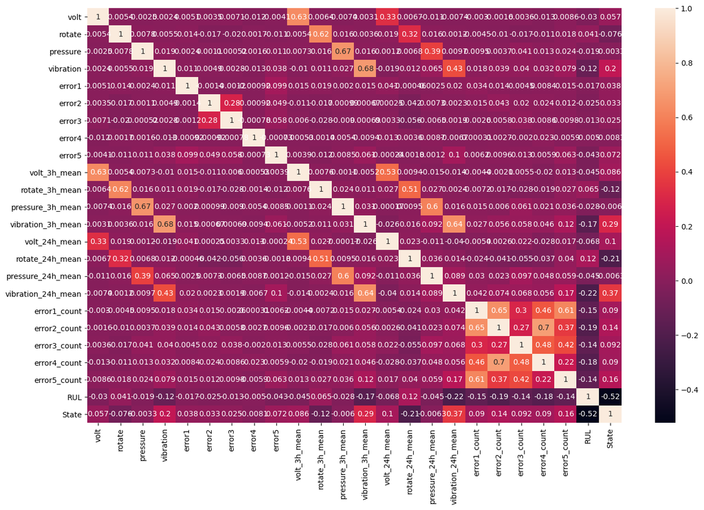

```python
#All variables correlations
plt.figure(figsize=(16, 10))
sns.heatmap(machine_m3_rul_train.corr(), annot=True)
```

# Train/Test Datasets

```python
machine_m3_rul_train = machine_m3_rul_cycle_cut.drop(['datetime', 'machineID', 'model', 'age', 'comp1', 'comp2', 'comp3', 'comp4', 'failure'], axis=1)
machine_m3_79_rul = machine_m3_79_rul_cycle_cut.drop(['datetime', 'machineID', 'model', 'age', 'comp1', 'comp2', 'comp3', 'comp4', 'failure'], axis=1)
```

```python
X_train = machine_m3_rul_train.loc[:, machine_m3_rul_train.columns != 'RUL']
y_train = machine_m3_rul_train.loc[:, machine_m3_rul_train.columns == 'RUL']
X_test = machine_m3_79_rul.loc[:, machine_m3_79_rul.columns != 'RUL']
y_test = machine_m3_79_rul.loc[:, machine_m3_79_rul.columns == 'RUL']

print(f"X_train: {len(X_train)}")
print(f"y_train: {len(y_train)}")
print(f"X_test: {len(X_test)}")
print(f"y_test: {len(y_test)}")
```

```
X_train: 17280
y_train: 17280
X_test: 3600
y_test: 3600
```

```python
X_train.to_csv('C:/Users/NetRunner/OneDrive/UOC/Semestre 6/TFM/MultipleDatasets/X_train.csv', encoding='utf-8', index=False)
y_train.to_csv('C:/Users/NetRunner/OneDrive/UOC/Semestre 6/TFM/MultipleDatasets/y_train.csv', encoding='utf-8', index=False)
X_test.to_csv('C:/Users/NetRunner/OneDrive/UOC/Semestre 6/TFM/MultipleDatasets/X_test.csv', encoding='utf-8', index=False)
y_test.to_csv('C:/Users/NetRunner/OneDrive/UOC/Semestre 6/TFM/MultipleDatasets/y_test.csv', encoding='utf-8', index=False)
```